# Statistical Inference in Biology Assignment 1

201900700284 Yang Sihao

2021/3/21

# 1、The Null and alternative hypotheses.

H0<-milk caps are Poisson distributed around the forest， H1<-milk caps are NOT Poisson distributed around the forest

# 2、The model and statistical test.

Poisson Distribution, Poisson distribution is used to calculate the probability of an event occurring over a certain interval.

χ2 Statistic, χ2 Statistic could evaluate the distance between the two distributions.

# 3、Generate the expected values (counts) based on a fitted Null model.

Import the milkcap.csv

```r
milkcap.df <- read.csv("milkcap.csv.", stringsAsFactors = T)
milkcap.df
```

```
##   specimens count
## 1         0   203
## 2         1    39
## 3         2    18
## 4         3    13
## 5         4    15
```

Calculate the weighted average of specimens and count

```r
milkcaps.mean<-weighted.mean(milkcap.df$specimens,milkcap.df$count)
```

Calculate expected count of extinctions λ.

“We do not know the true value of the expected count, the λ. To know it, we would need to collect and analyze all the milkcaps data on the Earth. It is of course not feasible (similarly as measuring all the wood ducks in the world). We will need to estimate λ from the sample μ: λ=μ” (PS:this paragraph is quoted from the solution4 of workshop4)
$$\mu=\lambda$$

Calculate Poisson distribution using the expected count λ.

“Create a vector variable with the sequence of extinction between 0 and 4:milkcap.range” “Calculate probabilities from the Poisson distribution, use milkcaps.mean as the parameter lambda” “We need to calculate the expected frequencies from the probabilities knowing that the marginal sum of expected must be equal do the marginal sum of observed” (PS:these paragraphs are quoted from the solution6 of workshop4)

```r
milkcap.range<-0:4
p<-dpois(milkcap.range,lambda = milkcaps.mean)
expected<-p*sum(milkcap.df$count)
expected
```

```
## [1] 157.4005474  95.0961640  28.7269662   5.7852918   0.8738201
```

# 4、Make a plot or plots presenting the observed and the expected count.

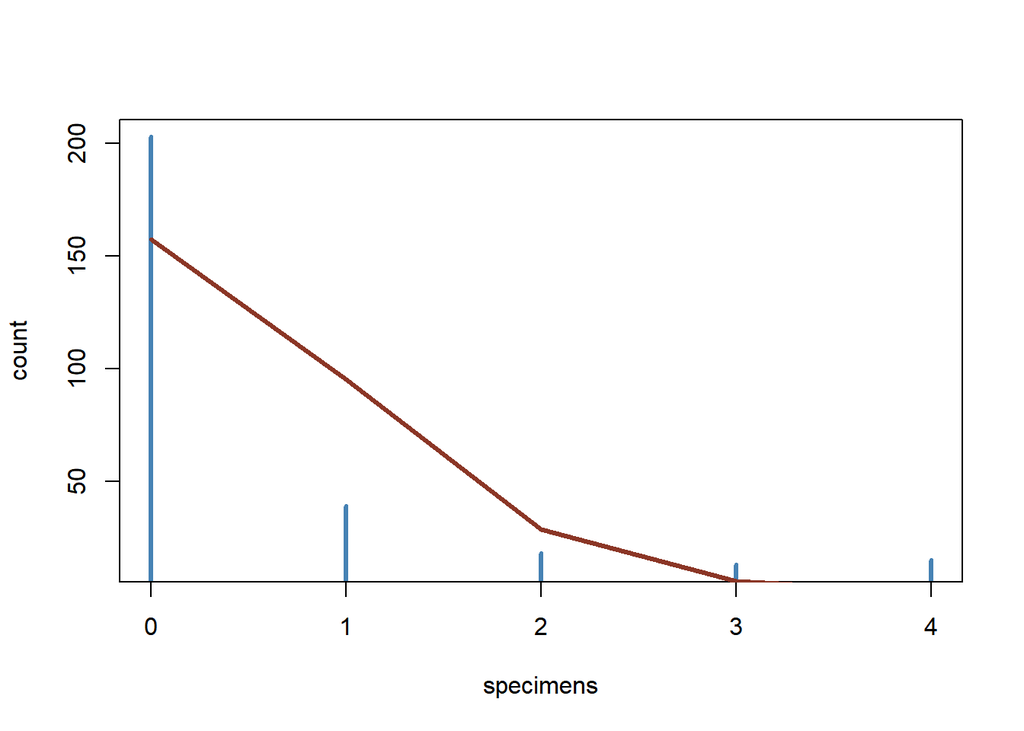

```r
plot(milkcap.df$specimens, milkcap.df$count,
     type = "h",
     lwd = 3,
     col = "steelblue",
     xlab="specimens",
     ylab="count")
lines(milkcap.df$specimens, expected,     lwd = 3,
     col = "tomato4",)
```

# 5、Perform the statistical test observing its assumptions.

Add the expected count to the milkcaps dataframe as a new column count_expected.

```r
milkcap.df$count_expected<-round(expected,2)
milkcap.df
```

```
##   specimens count count_expected
## 1         0   203         157.40
## 2         1    39          95.10
## 3         2    18          28.73
## 4         3    13           5.79
## 5         4    15           0.87
```

Calculate the χ2 statistic and find the probability of H0, the p-value.

```r
chisq<-chisq.test(milkcap.df$count,p=milkcap.df$count_expected,rescale.p = T)
chisq
```

```
##
##  Chi-squared test for given probabilities
##
## data:  milkcap.df$count
## X-squared = 288.67, df = 4, p-value < 2.2e-16
```

# 6、Conclusion:

This problem is to determine if milk caps are randomly distributed around the forest.

I use the expected of Poisson distribution and the observed to calculate the χ2 statistic and the probability of H0, the p-value to judge if the milk caps are fitted Poisson distribution.

We can confirm that the milk caps are not randomly distributed.

The research is not perfect because the number of sample is not enough.